# Homework 6

Broderick Prows

2/8/2020

Do the following using R. You must also turn in a copy of your R code.

Part 1

During the 1940s and 1950s, Ted Williams played baseball for the Boston Red Sox and Joe DiMaggio played for the New York Yankees. They were regarded as among the best players of their day, and the question of who was better was the subject of many heated arguments among baseball aficionados. Williams had the better batting record. Was he in fact a better hitter? Their major league career statistics are given in Table 1.

Table 1. Career Major League Baseball Statistics for Ted Williams and Joe DiMaggio

| Player | At Bats | Hits | Batting Average | Home Runs | Home Run Average |
| --- | --- | --- | --- | --- | --- |
| Ted Williams | 7706 | 2654 | .3444 | 521 | .0676 |
| Joe DiMaggio | 6821 | 2214 | .3246 | 361 | .0529 |

Assume that at-bats are exchangeable for each player. (This assumption is only approximately correct for me. Players learn, change their batting style from time to time, and get older. Moreover, they do not always play in the same ball park, against the same pitcher, in the same weather, the style of ball may change, and so on. But the assumption may not be far off. And if we do not assume something, we will not be able to draw any conclusions!)

1. First consider hits. A baseball afficionado’s prior probabilities concerning these two players’ “true proportions” of hits are given by independent beta(a, b) densities, where a = 50 and b = 120. (The values of a and b we assume do not matter much. Both Williams and DiMaggio had so many at-bats that we would get about the same answer even if we were to assume a = b = 1.) Find this fan’s posterior probability (given the preceding career statistics) that Ted Williams was a better hitter than Joe DiMaggio. (Interpret better to mean that there was a higher proportion of hits in the Williams model.)

```r
p_a <- 50
p_b <- 120
J <- 10000
ab_w <- 7706
hits_w <- 2654
a_star_w <- p_a + hits_w
b_star_w <- p_b + ab_w - hits_w
sim_w <- rbeta(J, shape1 = a_star_w, shape2 = b_star_w)

ab_d <- 6821
hits_d <- 2214
a_star_d <- p_a + hits_d
b_star_d <- p_b + ab_d - hits_d
sim_d <- rbeta(J, shape1 = a_star_d, shape2 = b_star_d)

diffs <- sim_w - sim_d
mean(diffs > 0)
```

```
## [1] 0.9945
```

2. Find this fan’s 95% posterior probability interval for the increase in the hitting success proportion for Williams over DiMaggio (that is, for θW − θD).

```r
quantile(diffs,c(.025, .975))
```

```
##        2.5%       97.5%
## 0.004542992 0.034761204
```

3. Plot the (estimated) posterior density of θW −θD (in black) and the (estimated) prior density of θW −θD (in gray) on the same plot. Make sure to properly label all plot components.

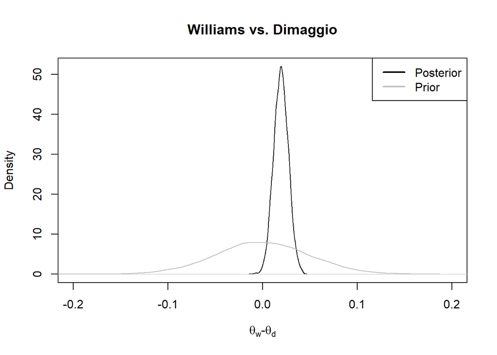

```r
prior_diffs <- rbeta(J, p_a, p_b) - rbeta(J, p_a, p_b)
plot(density(diffs), col = 'black', type = 'l',
     xlim = c(-.2,.2),
     main = "Williams vs. Dimaggio",
     xlab = expression(paste(theta['w'], '-', theta['d'])),
     ylab = 'Density')
lines(density(prior_diffs), col = 'gray')
legend("topright", legend=c("Posterior", "Prior"),
       col=c("black", "gray"), lty = 1, lwd = 2, cex = 1)
```

```r
p_hr_a <- 20
p_hr_b <- 200
hr_w <- 521
hr_d <- 361
a_star_w <- p_a + hr_w
b_star_w <- p_b + ab_w - hr_w
sim_w <- rbeta(J, shape1 = a_star_w, shape2 = b_star_w)

ab_d <- 6821
hits_d <- 2214
a_star_d <- p_a + hr_d
b_star_d <- p_b + ab_d - hr_d
sim_d <- rbeta(J, shape1 = a_star_d, shape2 = b_star_d)

diffs <- sim_w - sim_d
mean(diffs > 0)
```

```
## [1] 0.9995
```

5. Based on the answers to the previous four parts, what conclusion(s) if any should the fan draw in comparing the two baseball players? Be sure to thoroughly explain your answer.

The probability the Williams is a better hitter (both hits and home runs) is so high that we can conclude that Williams was a better hitter than Dimaggio, assuming that every at-bat is interchangable.

Part 2

To reinforce your understanding of prior-predictive distributions and posterior-predictive distributions we now consider predictions from the same baseball example. In baseball, one of the revered accomplishments is to have a batting average of .400 or above (baseball statistics always use three decimal places for a batting average) over the course of a season. This means that a player gets a hit in at least 40.0% of their at-bats during that season. As before, let θW represent the “true proportion” of hits for Ted Williams. We assume that Williams’ “true” but unobservable probability of getting a hit, θW , was constant over the course of his career (though, as discussed previously, there are reasons to doubt this assumption). Throughout all parts of this problem of the homework, we assume a Beta(50, 120) prior distribution for θW.

1. Suppose we knew that Williams would have five at bats in his first career game. What is the prior predictive probability that Williams would have at least a .400 (recorded) batting average after this first game? (That is, what is the prior predictive probability he gets at least two hits in his first five at bats, so that his recorded average is at least 2/5 =.400?) Recall that we assume the at-bats are conditionally iid, so that Ynew, first game|θW ∼ Binomial(nnew, first game = 5, θW ). Calculate the probability EXACTLY.

```r
prior_predictive <- function(ynew, nnew, a, b) {
  l.f.y <- lgamma(a+b) - lgamma(a) - lgamma(b) + lchoose(nnew,ynew) +
    lgamma(a+ynew) + lgamma(b+nnew-ynew) - lgamma(a+b+nnew)
  return(exp(l.f.y))
}
```

```r
p_a <- 50
p_b <- 120
n_new <- 5
y_cutoff <- n_new * .4 - 1
1 - sum(prior_predictive(ynew = 0:y_cutoff, nnew = n_new, a = p_a, b = p_b))
```

```
## [1] 0.45858
```

2. Refer to the previous question. Now, ESTIMATE the requested probability by appropriately using Monte Carlo.

```r
J <- 10000
y_new <- rbinom(J, n_new, rbeta(J, shape1 = p_a, shape2 = p_b))
mean(y_new > y_cutoff)
```

```
## [1] 0.4646
```

```r
p_a <- 50
p_b <- 120
n_new <- 650
y_cutoff <- n_new * .4 - 1
1 - sum(prior_predictive(ynew = 0:y_cutoff, nnew = n_new, a = p_a, b = p_b))
```

```
## [1] 0.005085443
```

4. Refer to the previous question. Now, ESTIMATE the requested probability by appropriately using Monte Carlo.

```r
J <- 10000
y_new <- rbinom(J, n_new, rbeta(J, shape1 = p_a, shape2 = p_b))
mean(y_new > y_cutoff)
```

```
## [1] 0.0045
```

5. The table of Williams’ actual batting career is provided above. We will suppose he had the chance to play one extra game right after this career, and that he would have five at-bats. Given our prior beliefs about θW and then the observed data from the table below, what is the probability that Williams would get at least two hits if he were to play one extra game at the end of his career, and we knew that he would have five at-bats? Calculate this posterior probability exactly.

```r
p_a <- 50
p_b <- 120
a_star <- p_a + hits_w
b_star <- p_b + ab_w - hits_w
n_new <- 5
y_cutoff <- n_new * .4 - 1
1 - sum(prior_predictive(ynew = 0:y_cutoff, nnew = n_new, a = a_star, b = b_star))
```

```
## [1] 0.5586261
```

6. Refer to the previous question. Now, ESTIMATE the requested probability by appropriately using Monte Carlo.

```r
J <- 10000
y_new <- rbinom(J, n_new, rbeta(J, shape1 = a_star, shape2 = b_star))
mean(y_new > y_cutoff)
```

```
## [1] 0.5546
```

7. We will suppose he had the chance to play one extra season right after his career, and that he would have 605 at-bats. Given our prior beliefs about θW and then the observed data from the table below, what is the probability that Williams would have a recorded batting average of at least .400 in this new season? Calculate this probability exactly. (Hint: we need the probability he would get at least 242 hits in the 605 new at-bats.)

```r
p_a <- 50
p_b <- 120
a_star <- p_a + hits_w
b_star <- p_b + ab_w - hits_w
n_new <- 605
y_cutoff <- n_new * .4 - 1
1 - sum(prior_predictive(ynew = 0:y_cutoff, nnew = n_new, a = a_star, b = b_star))
```

```
## [1] 0.002904066
```

8. Refer to the previous question. Now, ESTIMATE the requested probability by appropriately using Monte Carlo.

```r
J <- 10000
y_new <- rbinom(J, n_new, rbeta(J, shape1 = a_star, shape2 = b_star))
mean(y_new > y_cutoff)
```

```
## [1] 0.0028
```

1. Repeat the previous eight questions for Joe DiMaggio. We will use the same prior distribution for θD (i.e., the Beta(50, 120) distribution), but the posterior will be different because of DiMaggio’s different batting record.
1. First Game

```r
p_a <- 50
p_b <- 120
n_new <- 5
y_cutoff <- n_new * .4 - 1
1 - sum(prior_predictive(ynew = 0:y_cutoff, nnew = n_new, a = p_a, b = p_b))
```

```
## [1] 0.45858
```

2. Refer to the previous question. Now, ESTIMATE the requested probability by appropriately using Monte Carlo.

```r
J <- 10000
y_new <- rbinom(J, n_new, rbeta(J, shape1 = p_a, shape2 = p_b))
mean(y_new > y_cutoff)
```

```
## [1] 0.4609
```

```r
p_a <- 50
p_b <- 120
n_new <- 650
y_cutoff <- n_new * .4 - 1
1 - sum(prior_predictive(ynew = 0:y_cutoff, nnew = n_new, a = p_a, b = p_b))
```

```
## [1] 0.005085443
```

4. Refer to the previous question. Now, ESTIMATE the requested probability by appropriately using Monte Carlo.

```r
J <- 10000
y_new <- rbinom(J, n_new, rbeta(J, shape1 = p_a, shape2 = p_b))
mean(y_new > y_cutoff)
```

```
## [1] 0.0038
```

5. Extra Game (5 AB)

```r
p_a <- 50
p_b <- 120
a_star <- p_a + hits_d
b_star <- p_b + ab_d - hits_d
n_new <- 5
y_cutoff <- n_new * .4 - 1
1 - sum(prior_predictive(ynew = 0:y_cutoff, nnew = n_new, a = a_star, b = b_star))
```

```
## [1] 0.5201804
```

6. Refer to the previous question. Now, ESTIMATE the requested probability by appropriately using Monte Carlo.

```r
J <- 10000
y_new <- rbinom(J, n_new, rbeta(J, shape1 = a_star, shape2 = b_star))
mean(y_new > y_cutoff)
```

```
## [1] 0.5201
```

```r
p_a <- 50
p_b <- 120
a_star <- p_a + hits_w
b_star <- p_b + ab_w - hits_w
n_new <- 605
y_cutoff <- n_new * .4 - 1
1 - sum(prior_predictive(ynew = 0:y_cutoff, nnew = n_new, a = a_star, b = b_star))
```

```
## [1] 0.002904066
```

8. Refer to the previous question. Now, ESTIMATE the requested probability by appropriately using Monte Carlo.

```r
J <- 10000
y_new <- rbinom(J, n_new, rbeta(J, shape1 = a_star, shape2 = b_star))
mean(y_new > y_cutoff)
```

```
## [1] 0.0027
```

```r
J <- 10000
n_new <- 650
y_w <- rbinom(J, n_new, rbeta(J, shape1 = p_a, shape2 = p_b))
y_d <- rbinom(J, n_new, rbeta(J, shape1 = p_a, shape2 = p_b))
mean(y_w > y_d)
```

```
## [1] 0.4954
```

```r
J <- 10000
n_new <- 650
a_star_w <- p_a + hits_w
b_star_w <- p_b + ab_w - hits_w
a_star_d <- p_a + hits_d
b_star_d <- p_b + ab_d - hits_d
y_w <- rbinom(J, n_new, rbeta(J, shape1 = a_star_w, shape2 = b_star_w))
y_d <- rbinom(J, n_new, rbeta(J, shape1 = a_star_d, shape2 = b_star_d))
mean(y_w > y_d)
```

```
## [1] 0.7536
```